# Maintain your brain, Primary Cognitive Composite Variable, Imputed

## cogmeanz_full

- Primary Cognitive Composite Variable
  - Cogstate Detection
  - Cogstate Identification
  - Cogstate One Back
  - Cambridge Brain Sciences Spatial (tokens) Search
  - Cambridge Brain Sciences Grammatical Reasoning
  - Cogstate One Card Learning
  - Cambridge Brain Sciences Paired Associates

```r
# read in functions and data
library(tidyverse)
library(mice)
library(emmeans)
library(broom.mixed)
emm_options(pbkrtest.limit = 1000)
load( file ="../../MI/imputed_wrangeld_25") # loads imp_mids
```

Inference for differences in rc_trial_time trend by group_type_id for cogmeanz_full

Summary of two of the imputed datasets

```r
complete(imp_mids, action = "long", include = TRUE) %>%
  filter(.imp %in% 1:2) %>%
  group_by(.imp, rc_trial_time, group_type_id) %>%
  summarize_at(.vars = params$response, .funs = list(Mean = mean, Sd = sd, N_obs = ~length(.)), na.rm=T)
```

```
## # A tibble: 16 x 6
## # Groups:   .imp, rc_trial_time [8]
##     .imp rc_trial_time group_type_id    Mean    Sd N_obs
##    <int> <fct>         <fct>           <dbl> <dbl> <int>
##  1     1 1             1              0.0203 1.00   3053
##  2     1 1             2             -0.0180 0.996  3051
##  3     1 10            1              0.229  0.989  3053
##  4     1 10            2              0.362  0.984  3051
##  5     1 11            1              0.211  0.991  3053
##  6     1 11            2              0.369  0.995  3051
##  7     1 12            1              0.117  1.01   3053
##  8     1 12            2              0.289  1.01   3051
##  9     2 1             1              0.0203 1.00   3053
## 10     2 1             2             -0.0180 0.996  3051
## 11     2 10            1              0.218  0.995  3053
## 12     2 10            2              0.368  0.981  3051
## 13     2 11            1              0.203  1.01   3053
## 14     2 11            2              0.389  0.984  3051
## 15     2 12            1              0.135  1.01   3053
## 16     2 12            2              0.261  1.01   3051
```

## Results

```r
mod_imp <- with(data = imp_mids, exp = lme4::lmer(cogmeanz_full ~  #unadjusted
                                               rc_trial_time * group_type_id + (1|id_mask)))

mod_imp_0 <- with(data = imp_mids, exp = lme4::lmer(cogmeanz_full ~  #unadjusted
                                                 rc_trial_time + group_type_id + (1|id_mask)))

aov = anova(mod_imp,mod_imp_0)

em_imp <- emmeans(mod_imp,  ~ rc_trial_time * group_type_id,
                  at = list(rc_trial_time = as.factor(c(1,12)) ))
cont_imp <- contrast(em_imp, interaction = c("consec", "consec"))
cond_sum <- summary(cont_imp)
CI_imp <- confint(cont_imp)
  Su <- summary(cont_imp)
  p_0_4 <- data.frame()

anova_call <- aov$out$`1 ~~ 2`$result %>%  as.data.frame()
res_tab <- data.frame(response = "cogmeansz_full_imputed",
                      adjusted = "No",
                      base_3yr_did = round(cond_sum$estimate, 3),
                      LCL = round(CI_imp$asymp.LCL, 3),
                      UCL = round(CI_imp$asymp.UCL,3),
                      zstat = round(Su$z.ratio,3),
                      pz = ifelse (Su$p.value < 0.001, "<0.001",paste("= ",round(Su$p.value,3))),
                      Fstat = paste0(round(anova_call$F.value,3)," (",
                                       round(anova_call$df1,0),",",round(anova_call$df2,0), ")"),
                      p.value = ifelse (anova_call$`P(>F)` < 0.001, "<0.001", paste("= ",round(anova_call$`P(>F)`,3))))



res_tab
```

```
##                 response adjusted base_3yr_did  LCL   UCL zstat     pz
## 1 cogmeansz_full_imputed       No        0.193 0.14 0.246 7.164 <0.001
##            Fstat p.value
## 1 25.357 (3,344)  <0.001
```

```r
evidence_unadj = ifelse(res_tab$p.value[1]<0.05, "evidence", "no evidence")
```

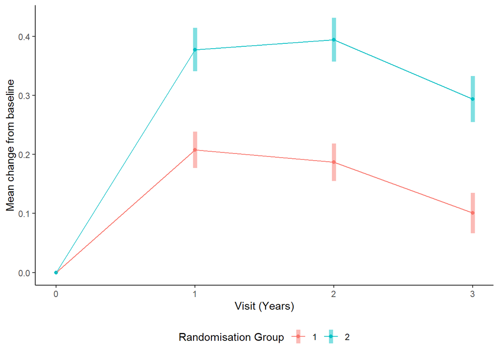

```r
# calculate all ems by time and group
group_time_ems <- emmeans(mod_imp,  ~ group_type_id + rc_trial_time)

# contrast to baseline by group
comp_to_baseline <- contrast(group_time_ems, rc_trial_time , "trt.vs.ctrl", by=  "group_type_id")


to_bl_plot_df <- cbind(summary(comp_to_baseline)[,1:3],
                       confint(comp_to_baseline)[,6:7],
                       `Visit (Years)` = rep(c(1:3), 2))
# add baseline 0
to_bl_plot_df[7:8,] <- NA
to_bl_plot_df$group_type_id[7:8] = c(1,2)
to_bl_plot_df$estimate[7:8] = c(0,0)
to_bl_plot_df$`Visit (Years)`[7:8] = 0


to_bl_plot_df %>%
  ggplot(aes(`Visit (Years)`, estimate,color=factor(group_type_id), group=factor(group_type_id))) +
  geom_point() +
  geom_line()+
  geom_linerange(aes(ymin=asymp.LCL, ymax=asymp.UCL), size=2, alpha=.5) +
  theme_classic() +
  ylab("Mean change from baseline") +
  scale_color_discrete(name="Randomisation Group")  +
   theme(legend.position = "bottom")
```

```r
ggsave(file = paste0(params$response,"_",params$data,"_plot.png"), width = 12, height = 8, units = "cm")



to_bl_plot_df %>%
  transmute(group_type_id, `Visit (Years)`,
         estimate,
         LCL = asymp.LCL, UCL = asymp.UCL) %>%
  arrange(`Visit (Years)`,group_type_id) %>%
write.csv(file = paste0(params$response,"_",params$data,"_plotdata.csv"), row.names = FALSE)
```

```

## Result

Data was imputed 25 times for all outcome variables jointly using the variables listed above using the mice package (Buuren et. al) in R. We use a mixed model imputation method with homogeneous variance within clusters (method 2l.pan) to account for repeated measurements.

Variables for imputation model:

Analysis model variables

- group_type_id
- rc_trial_time
- group_type_id * rc_trial_time

Other variables

- myb_age
- myb_gender
- cl_edu_yrs
- rcal_modules_sum
- adri_baseline
- Online modules: rcal_eligibility_bts, rcal_eligibility_pom, rcal_eligibility_pa, rcal_eligibility_diet
- rc_race: race
- rc_preflang: preferred language
- rc_leqses: SES
- Various baseline scores and status indicators:
  - CalcK10Score
  - rcal_mybBMI
  - rcal_total_energy
  - PREDIMEDTotal,
  - smoking
  - everchol
  - everbp
  - LLS
  - CalcAnxietyScore
  - rc_phq9_total
  - rc_wellb_status
  - rc_paqu_status
  - rc_medh_status
  - rc_leq_status
  - rc_diet_status
  - rc_adri_status
  - rc_myb1_status

A linear mixed model with a random effect for individual and fixed effects of time point, randomisation group and their interaction was run. We report estimates of the group difference in the change from baseline to three years follow up with 95% confidence interval, and associated Z statistic and p-value. The units of the effect size are standard deviations at baseline.

The unadjusted difference between randomisation groups of change from baseline to three year follow up was 0.193 ( 95%CI: 0.14- 0.246,Z=7.164, p<0.001) baseline standard deviations.

Analysis by Nancy Briggs and Gordana Popovic on 2024-02-14

## References

Li, K. H., T. E. Raghunathan, and D. B. Rubin. 1991. Large-Sample Significance Levels from Multiply Imputed Data Using Moment-Based Statistics and an F Reference Distribution. Journal of the American Statistical Association, 86(416): 1065–73.

Stef van Buuren, Karin Groothuis-Oudshoorn (2011). mice: Multivariate Imputation by Chained Equations in R. Journal of Statistical Software, 45(3), 1-67. URL https://www.jstatsoft.org/v45/i03/.